# Lab 7: Accurate Against What?

Accuracy assessment, area estimation, and the cost of a self-test

Author

Dr. Francisco Laso, ESCI 442/542 — Introduction to Remote Sensing

Lab 7 Module 7 — Accuracy Assessment

**Readings due before lab:** Campbell Ch. 13 — Accuracy Assessment | Cardille Ch. F7 — Quantifying Classification Quality | Olofsson et al. (2014) — *Remote Sensing of Environment* 148:42–57

## Background

In Lab 6 we built a five-class land-cover classifier over the Salish Sea bioregion. The Random Forest map looked plausible and the visual comparison against the Salish Sea Atlas put it in roughly the right neighborhood. But “looks plausible” is not a defensible answer to the question every map invites: *how accurate is it?* In Lab 7 we take that map and ask the question quantitatively. The answer turns out to depend less on the map and more on the *reference* we choose to compare it against — and on the design of the sample we draw from that reference.

The discipline has a name for that dependency. In conservation biology there is a concept called a *shifting baseline*: every generation unconsciously accepts the environment they grew up with as “normal,” even if it has already been dramatically degraded. A 5 % increase in fish population sounds encouraging until you learn populations declined 70 % over the last few decades, and even that may be tiny compared to what existed 200 years ago. The number is meaningless without a reference, and the reference itself carries history and uncertainty. The same logic governs accuracy assessment in remote sensing. When we say a classified map is “accurate,” we mean accurate *relative to* something: a held-out training subset, a stratified probability sample, a published continental-scale product like NALCMS, expert visual interpretation. Each reference is a different baseline. Each gives a different number. Lab 7 makes that fact concrete by computing the same accuracy two different ways on the same map and watching them disagree.

The lab is built around a deliberate contrast. We compute two error matrices over the same Lab 6 Random Forest classification. The first uses the 30 % random holdout we exported from L6.2 — convenient, easy, and what most published student projects and many production reports actually do. We will frame this number as *internal validation*: a self-test against a random subset of the same labeled pool that trained the classifier. The second uses a fresh, independent sample we draw stratified by mapped class directly over the classified map and label point-by-point against high-resolution imagery. We compute Olofsson et al. (2014)’s proportional-area error matrix and place 95 % confidence intervals on the resulting overall, user’s, and producer’s accuracies. The two numbers will not agree. The gap between them is the central thing this lab teaches.

A small detour into kappa, the metric Cardille Ch. F7’s `errorMatrix` API returns by default. Kappa attempts to correct overall accuracy for the agreement we would expect by chance. The remote sensing community has broadly deprecated it — Campbell §13.4 summarizes the critique — because it is redundant with overall accuracy, tends to overestimate chance agreement, and underestimates the probability that any given pixel is correctly classified. We compute kappa in this lab because we will encounter it in published literature, but we treat it as a historical artifact and close the lab reporting overall, user’s, and producer’s accuracy with confidence intervals instead.

**Note**

**Lab Objectives**

By the end of this lab you will be able to:

1. Build an error matrix from a classified map and a labeled reference set, and read overall, user’s, and producer’s accuracy off it (Cardille Ch. F7; Campbell §13.4)
2. Distinguish a self-test against a random training-pool holdout from a defensible accuracy assessment against an independent probability sample (Olofsson et al. 2014, §1)
3. Design a stratified random reference sample, allocate it across mapped classes, and explain why stratification matters when one class is rare (Olofsson et al. 2014, §2; Campbell §13.5)
4. Convert sample counts to a proportional-area error matrix and compute accuracy estimates with 95 % confidence intervals (Olofsson Eqs. 4–7; Campbell §13.8)
5. Estimate corrected per-class area from the reference-based matrix, with a confidence interval, and compare it to the area we would get by counting mapped pixels directly (Olofsson Eqs. 9–11; Campbell §13.10)
6. Apply McNemar’s test to determine whether two classifiers (CART vs. Random Forest) are statistically distinguishable on the same reference set (Campbell §13.9)
7. Read the kappa coefficient and explain why the field has moved past it as a recommended metric (Campbell §13.4; Olofsson 2014 §4.3)

**Warning**

**Before You Begin**

## Part 1 — From Classifier to Accuracy

The Lab 6 Random Forest map exists as a colored raster. To go from a colored raster to a number — *the map is X percent accurate* — we need three things: a *reference dataset* (a set of locations whose true class we know by some method we trust more than the classifier), a *spatial unit* at which map and reference are compared (here, the 30 m Landsat pixel), and a *rule for agreement* (here, identity: the mapped class equals the reference class). The compact representation of all that comparison is the *error matrix*: a 5 × 5 table whose rows are mapped classes, whose columns are reference classes, and whose cell (i, j) is the count of points the map called class i and the reference called class j. The diagonal cells are agreements; the off-diagonal cells are confusions.

From the error matrix, three accuracies fall out (Campbell §13.4; Cardille F7 §7.2). *Overall accuracy* is the proportion of all points the map got right — the sum of the diagonal divided by the total. *User’s accuracy* for class i is the proportion of points the map called class i that the reference confirmed — the diagonal cell divided by the row total — and answers the question *“if the map says Forest, how often is it actually Forest?”* (the perspective of the map’s user). *Producer’s accuracy* for class j is the proportion of points the reference called class j that the map also called class j — the diagonal cell divided by the column total — and answers the question *“of the actual Forest in the world, how much did the map find?”* (the perspective of the map’s producer). Omission errors and commission errors are simply the failure-side rephrasings of the same numbers: omission for class j is `1 - PA[j]`, commission for class i is `1 - UA[i]`. Three numbers, three perspectives — a single overall accuracy is never enough.

The L6.2 holdout is the simplest possible reference. We split the labeled training pool 70 / 30 before training, kept the classifier away from the held-out 30 %, and reserved the holdout exactly for the moment we are in now: classify those points with the trained Random Forest, build the error matrix, read the accuracies. Script L7.1 does exactly that, and it produces a number — typically in the high 80s — that we will print and inspect. But before we celebrate, we should be honest about what the number means. The holdout was drawn from the same labeled pool that trained the classifier. It inherits any class-balance, geographic, or spectral biases that pool carried. It does not constitute an independent probability sample over the *mapped surface*. It tests how well the classifier reproduces the labels of points it never saw, which is a different question than how well the map represents land cover in the world. Olofsson et al. (2014) §1.1 are explicit on the point: a defensible accuracy assessment requires a probability sample whose units are independent of the data used to train the classifier. Random subsetting of the training pool does not satisfy that requirement. The number is useful — it is what most reports actually do, and it is the natural baseline — but it is a self-test, and we will treat it as such.

**Note**

**Script L7.0 covers:**

The L7.0 introduction script orients us to the Lab 7 arc, prints the reference-protocol comparison plan, confirms that the L6.2 holdout and training assets load correctly, and re-displays the Lab 6 Random Forest classification.

**Note**

**Script L7.1 covers:**

The L7.1 script loads the L6.2 holdout asset, applies the re-trained Lab 6 Random Forest, builds the count-form error matrix, and prints overall, user’s, and producer’s accuracy along with kappa. Confirm Checkpoint **L7-CP1** before continuing. The number you see is the self-test baseline — hold it in mind as you work through Parts 3 and 4, where we compute the independent-reference counterpart.

## Part 2 — Designing a Defensible Reference Sample

A defensible accuracy assessment starts not with a classifier but with a *sample design*. Olofsson et al. (2014) §2 walk through what that means: the reference units must be drawn by a *probability sample* — every unit in the bioregion has a known, positive chance of being selected — and the sampling plan must be documented so that someone reading the accuracy report can evaluate it. The choice that matters most for an undergraduate land-cover map is *what to stratify by*. Stratification means dividing the bioregion into non-overlapping subpopulations and drawing reference units from each one separately. The natural stratification when the goal is per-class accuracy is *the mapped classes themselves* — we draw a fixed number of reference points from each mapped class and label them. This guarantees that even rare classes (here, Snow/Ice on Mt. Baker, Mt. Olympus, and Glacier Peak) receive enough reference points to compute a meaningful per-class accuracy.

The alternative — *simple random sampling* without stratification — is what happens when we draw 75 points from across the bioregion uniformly and accept whatever class distribution we get. For a class that occupies roughly 1 % of the mapped surface, simple random gives us about *one* reference point in expectation. One point is not a sample; it is an anecdote. The user’s accuracy for Snow/Ice computed from one point is undefined or has a confidence interval so wide as to be useless. Olofsson §2.1.1 is unambiguous: simple random fails for rare classes. We will see this directly in EX1, when we re-run the assessment under simple random and watch Snow/Ice drop out of the matrix.

For the stratified sample we use 15 points per mapped class, 75 points total. The choice of 75 has two justifications worth stating. The first is operational: hand-labeling each point against high-resolution imagery takes roughly 20–40 seconds, putting the total labeling burden at about 30 minutes inside a single class period and leaving time for the analysis in Part 4. The second is design parity: Lab 6’s L6.2 holdout produces approximately 75 points (50 per class × 5 classes × 30 % split), so matching the stratified sample to 75 keeps the L7.1-versus-L7.3 comparison clean — only the sample design and the reference independence vary, not the number of reference units. Equal allocation (15 per class) is also a pedagogical choice. Olofsson §2.1.2 recommends a *compromise allocation* — boost rare classes above proportional, then allocate the remainder roughly proportional to class area — which gives smaller standard errors on overall accuracy at the cost of larger ones on rare-class user’s accuracy. We use equal allocation for clarity here; the compromise allocation is part of the EX1 discussion.

Worth saying out loud: the Olofsson worked example in §5 uses n = 641. Production-grade accuracy reports routinely use 500–1000. Our n = 75 will produce visibly wide confidence intervals. That is by design — wide intervals make the cost of a small reference sample visible rather than hiding it behind a single point estimate.

**Note**

**Script L7.2 covers:**

The L7.2 script generates the stratified random reference sample from the Lab 6 classified raster, displays the points colored by mapped class so we can inspect them, and exports the FeatureCollection to a GEE asset and a Drive CSV for the manual labeling step in Part 3. Confirm Checkpoint **L7-CP2** before moving on.

## Part 3 — Manual Reference Interpretation

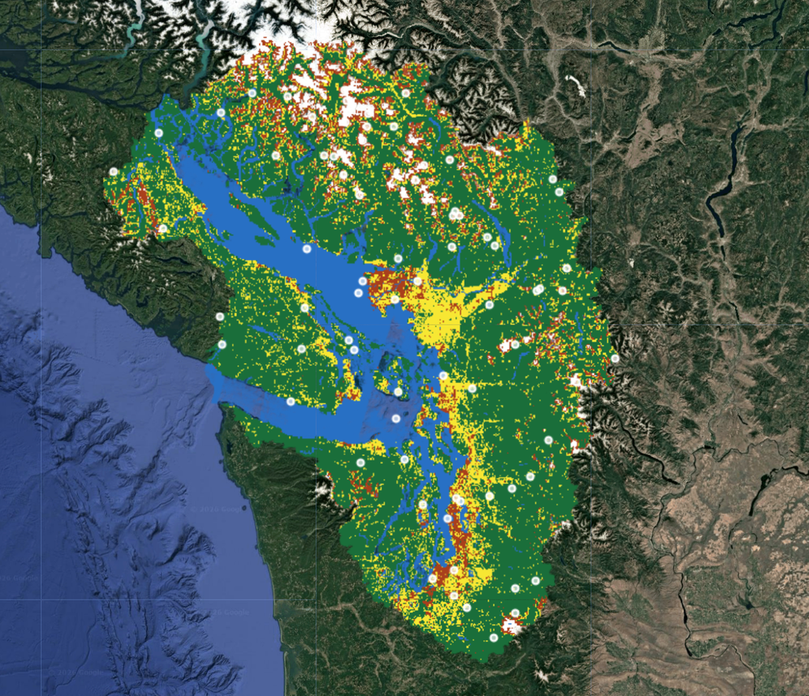

### Setting up the imagery in ArcGIS Pro

The exported CSV contains `point_id`, `longitude`, `latitude`, `mapped_class`, `class_code`, and a `reference` column initialized to `−9` (a sentinel meaning “not yet labeled”). Import it with **Map** tab → **Add Data** → **XY Point Data**; set X field = `longitude`, Y field = `latitude`, coordinate system = *GCS WGS 1984 (WKID 4326)*.

The Lab 6 classification was built from Landsat 8 imagery composited between **29 June 2020 and 15 September 2020**. To compare each reference point against imagery from roughly that same growing season, apply the World Imagery time filter: right-click the basemap layer → **Properties** → **Time** tab → check *“Show the layer when the map is within a fixed time extent”* → set the Visible Time Extent to `6/29/2020` – `9/15/2020` → click OK.

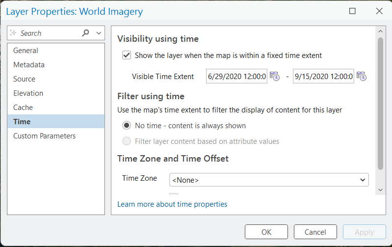

World Imagery Layer Properties — Time tab. Set the Visible Time Extent to the Lab 6 composite date range so the basemap reflects 2020 summer conditions.

If you do not have access to ArcGIS Pro, **Google Earth Pro** (free) provides a historical imagery slider — click the clock icon in the toolbar and drag the slider to summer 2020 — which gives you equivalent date-matched high-resolution imagery without requiring an ArcGIS license.

### Labeling each point

For each of the 75 rows, navigate to the point using the `longitude` and `latitude` values, inspect the high-resolution imagery in the immediate 30 m Landsat-pixel neighborhood, and decide what class it actually is. The decision rule is the same as for Lab 6 training-point collection: assign the class that *dominates* the 30 m neighborhood around the marker. For ambiguous points — mixed-pixel boundaries, forest-farmland edges in the Cascades foothills — make the best judgment call and assign the more dominant class. Replace the `−9` sentinel in the `reference` column with the appropriate integer (0 = Forest, 1 = Developed, 2 = Water, 3 = Herbaceous, 4 = Snow/Ice). Olofsson et al. (2014) §3.5 recommend recording an interpreter-confidence flag for each point; we do not implement that here, but worth keeping in mind: every reference label is itself an act of interpretation.

The figures below show examples of the labeling judgment for three commonly confused class pairs.

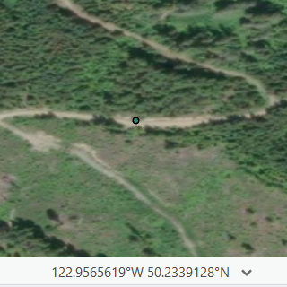

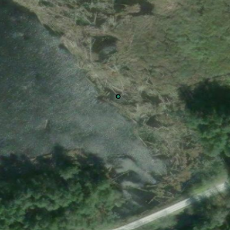

Water-land boundary point. The marker sits at the edge of a tidal flat; the decision depends on whether water or exposed sediment dominates the 30 m neighborhood at the time of image acquisition.

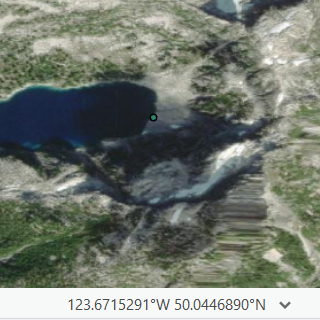

Water or Ice/Snow? High-elevation points may be shadowed glacial meltwater pools (Water) or permanent snowfields (Snow/Ice). Use elevation context and surrounding terrain to decide.

### Re-uploading to the labeled-asset path (alternative)

If editing 75 rows in the GEE table view is unwieldy, download the CSV export from your Drive folder and label it outside GEE. The exported file contains `point_id`, `longitude`, `latitude`, `mapped_class`, `class_code`, and a blank `reference` column — you only need to fill in that last column (integer 0–4 for each row). Two good options:

- **Spreadsheet (Google Sheets / Excel)** — open the CSV, use the longitude and latitude values to find each point on Google Maps or Google Earth Pro, and type the reference class code directly in the `reference` column.
- **ArcGIS Pro** — go to **Map** tab → **Add Data** → **XY Point Data**. Set X field = `longitude`, Y field = `latitude`, coordinate system = *GCS WGS 1984 (WKID 4326)*. The 75 points appear as a feature layer over your basemap. Set the World Imagery time filter as described above (Properties → Time → 6/29/2020 – 9/15/2020), then edit the `reference` field in the attribute table for each point. When done, export the layer to CSV (**Right-click layer** → **Data** → **Export Table**).

Once labeled, re-upload the CSV to GEE via Asset Manager → **New** → **Table Upload** and name it `lab7_strat_sample_labeled` (or your chosen path). The result is identical to the in-browser edit: a FeatureCollection with both `classification` (mapped class) and `reference` (your interpreted class) on each feature.

**Warning**

**Common mistakes during reference interpretation**

- **Labeling against the classified map instead of the high-resolution basemap.** If the RF Classification layer is selected or on top in your ArcGIS Pro layer stack, you may inadvertently judge each point against the map’s own prediction rather than real-world imagery — which gives you 100 % accuracy by definition. Before navigating to each point, confirm that the World Imagery basemap is visible and on top.
- **Leaving the `reference` column as text.** The exported CSV initializes `reference` as `-9` (a numeric sentinel meaning “not yet labeled”). Replace each `-9` with the correct integer class code (0 = Forest, 1 = Developed, 2 = Water, 3 = Herbaceous, 4 = Snow/Ice). If a spreadsheet or GIS program converts the column to text during editing, GEE’s `errorMatrix` will compare a string (“3”) against an integer (3) and find no matches — producing an all-zeros count matrix and 0 % accuracy across the board. Before re-uploading, confirm the `reference` column is stored as a number type, not text. In ArcGIS Pro the field type should be **Long** (as shown in the Fields view); in Excel or Google Sheets the cells should be formatted as Number, not General or Text.
- **Re-uploading as a Shapefile (.shp) instead of CSV.** Shapefiles truncate field names to 10 characters. The column `mapped_class` (12 characters) will be silently renamed, which can cause confusion when re-loading the asset. Always export the labeled table as **CSV** and upload it via Asset Manager → New → CSV upload.
- **Using the original training points to label.** The point of an *independent* reference sample is that it is independent. Do not look up which class your Lab 6 training points said for nearby pixels — judge the pixel on the imagery alone.

**Note**

**Script L7.3 covers:**

The L7.3 script loads the labeled reference asset, computes per-class mapped-area weights `W[i]` from the bioregion classified raster using `pixelArea` and `reduceRegion`, builds the count-form error matrix from the labeled reference, and converts it to the proportional-area form per Olofsson 2014 Eq. 4. Confirm Checkpoint **L7-CP3**.

## Part 4 — From Counts to Area, with Confidence

The proportional-area error matrix is what makes Olofsson’s framework actually buy us something beyond Cardille’s `accuracy()` call. The conversion is one line of arithmetic: `p̂[i][j] = W[i] × n[i][j] / n[i]·`, where `W[i]` is the mapped-area proportion of class i and `n[i]·` is the row total. The interpretation is more interesting than the formula. Each `p̂[i][j]` is the *estimated proportion of total bioregion area* in mapped class i and reference class j. The whole matrix sums to 1.0. The diagonal sum is the overall accuracy. The row marginals are the mapped class proportions (the `W[i]` we started with). The column marginals are the *reference-based* proportions of each class in the bioregion — and those reference-based proportions are different from the mapped proportions whenever the classifier has commission or omission errors. That difference is what enables corrected area estimation.

Olofsson Eqs. 5–7 give variance estimators for OA, UA, and PA under the stratified-by-map-class design. The variance equations are mechanical applications of survey-sampling theory; the formulas in their full algebraic form are in Campbell §13.8 and in the lab’s master script for those who want to read them. What matters for interpretation is the result. Each accuracy estimate now comes with a 95 % confidence interval — *OA = X ± Y* — which tells us how much sampling variability is in our point estimate. At n = 75 and a reasonably accurate classifier, the OA half-width is typically in the 4–8 percentage-point range. That is wide. It is wide because the sample is small, and it is wide for a reason: an accuracy report that says *“OA = 87 %”* without a CI is hiding the fact that the true value could be anywhere from 80 % to 94 %. The CI is what makes the number scientifically usable.

Area estimation is the second-order payoff. If we counted pixels of the mapped Forest class and multiplied by the pixel area, we would get a *mapped* area — but mapped area is biased by the classifier’s commission and omission errors. The reference-based estimator (Olofsson Eq. 9) uses the column marginals of the proportional-area matrix to give an unbiased estimate of each class’s *actual* area in the bioregion, with its own confidence interval (Eq. 10). For a class with high commission error, the reference-based area estimate will be smaller than the mapped area; for a class with high omission error, it will be larger. The L7.4 script reports both numbers side by side.

The final move in Part 4 is the McNemar test. Lab 6 trained both CART and Random Forest classifiers on the same training data. The Lab 6 lab document asked us to compare them visually. Lab 7 asks the same question quantitatively: are the two classifiers’ error patterns *statistically distinguishable* on the same reference set? Campbell §13.9 gives the McNemar statistic — `z = (b − c) / √(b + c)` where `b` and `c` are counts of points one classifier got right and the other got wrong — and a 95 % significance threshold of `|z| > 1.96`. The L7.4 script prints `b`, `c`, the z-statistic, and the significance flag. The result tells us whether the visual difference between CART and RF is real (statistically significant on this reference) or whether it is within sampling noise.

**Note**

**Script L7.4 covers:**

The L7.4 script computes 95 % confidence intervals on overall, user’s, and producer’s accuracy using Olofsson Eqs. 5–7; computes corrected per-class area estimates with confidence intervals using Eqs. 9–11; and runs McNemar’s test comparing CART and Random Forest on the same stratified reference set (Campbell §13.9). Confirm Checkpoint **L7-CP4** before moving on.

## Part 5 — When Sampling Design Fails

The independent exercise in Lab 7 re-runs the same accuracy assessment under *simple random sampling* — 75 points drawn uniformly across the bioregion with no stratification by mapped class. Olofsson §2.1 predicts what will happen: the points fall in classes roughly in proportion to mapped area, which means Snow/Ice (~ 1 % of the bioregion) receives roughly *one* reference point, and Developed (~ 2–4 %) receives roughly *two to three*. The user’s and producer’s accuracies for those classes are either undefined or have confidence intervals so wide as to be useless. The simple-random error matrix tells us, in concrete terms, what stratification was actually doing.

The pedagogy here is not that simple random is bad in some abstract way. It is that *sample design choices have consequences* and those consequences are not theoretical — they show up as missing rows in the error matrix. The full discussion of why Olofsson recommends a compromise allocation rather than equal allocation connects EX1 directly to the design choice for your own final-project accuracy assessment.

**Note**

**Script EX1 covers:**

EX1 generates a simple random reference sample of 75 points over the bioregion, prints the per-class point distribution, and exports the sample for a parallel labeling pass if desired. Confirm Checkpoint **L7-EX1**.

## Key Estimators

The equations below are the computational core of the Olofsson (2014) framework. Each one maps directly to a line in the L7.3 / L7.4 console output, and each has a counterpart in Campbell §13.8.

Use the table below to record your own count-form error matrix from the L7.3 console output. Rows are mapped class; columns are reference class; diagonal cells are agreements.

|  | **Forest** | **Developed** | **Water** | **Herbaceous** | **Snow/Ice** | **Row *n*** | **UA** |
| --- | --- | --- | --- | --- | --- | --- | --- |
| **Forest** |  |  |  |  |  |  |  |
| **Developed** |  |  |  |  |  |  |  |
| **Water** |  |  |  |  |  |  |  |
| **Herbaceous** |  |  |  |  |  |  |  |
| **Snow/Ice** |  |  |  |  |  |  |  |
| **Col *n*** |  |  |  |  |  |  |  |
| **PA** |  |  |  |  |  |  |  |

**Proportional-area element** (Olofsson Eq. 4). Each cell is scaled by the mapped-area weight $W_i$ of its row class, so the whole matrix sums to 1.0:

$$\hat{p}_{ij} = W_i \cdot \frac{n_{ij}}{n_{i\cdot}}$$

where $n_{ij}$ is the sample count in row $i$, column $j$, and $n_{i\cdot}$ is the row total.

**Overall accuracy** — the diagonal sum of the proportional-area matrix:

$$\widehat{OA} = \sum_{i=1}^{q} \hat{p}_{ii}$$

**User’s accuracy** for mapped class $i$ — the proportion of reference points in that row confirmed by the reference (equal to the raw sample proportion because $W_i$ cancels):

$$\widehat{UA}_i = \frac{n_{ii}}{n_{i\cdot}}$$

**Producer’s accuracy** for reference class $j$ — the proportion of all reference points the map correctly found for that class:

$$\widehat{PA}_j = \frac{\hat{p}_{jj}}{\displaystyle\sum_{k=1}^{q} \hat{p}_{kj}}$$

**Variance of OA** (Olofsson Eq. 5) — used to place a 95 % CI on the overall accuracy estimate:

$$\hat{V}(\widehat{OA}) = \sum_{i=1}^{q} W_i^2 \cdot \frac{\widehat{UA}_i\,(1-\widehat{UA}_i)}{n_i - 1}$$

**Corrected area of class $j$** (Olofsson Eq. 9) — reference-based, unbiased estimate of the true areal extent of each class:

$$\hat{A}_j = A_{\text{total}} \sum_{i=1}^{q} W_i \, \frac{n_{ij}}{n_{i\cdot}}$$

**95 % confidence interval half-width** for any estimator $\hat{\theta}$ with variance $\hat{V}(\hat{\theta})$:

$$\text{CI}_{95\%} = 1.96\,\sqrt{\hat{V}(\hat{\theta})}$$

**McNemar’s z-statistic** (Campbell §13.9) — tests whether two classifiers differ significantly on the same reference set, where $b$ counts points Classifier A got right and B got wrong, and $c$ counts the reverse:

$$z = \frac{b - c}{\sqrt{b + c}}, \qquad |z| > 1.96 \;\text{is significant at}\; \alpha = 0.05$$

## Guiding Questions

**Tip**

**Guiding Questions for Your Technical Analysis**

Consider the following questions as you work through the lab and draft your technical analysis. They are thinking tools, not a required checklist — focus on the ones that most directly illuminate your own results.

- **Holdout self-test vs. independent assessment.** What specific independence requirement does a random training-pool split fail to satisfy (Olofsson §1.1)? Where could the resulting optimism show up in your particular map — is there a class for which the Lab 6 training points were clustered in one part of the bioregion or one phenological state?
- **Sample design and rare classes.** Compare the per-class point counts your stratified sample and your EX1 simple-random sample produced. Which class is most affected by the choice of design, and why? What would have to be true about the bioregion for simple random to work as well as stratified (Olofsson §2.1.1)?
- **Reading the proportional-area matrix.** Pick one off-diagonal cell — for example, mapped Forest / reference Herbaceous, or mapped Developed / reference Herbaceous. What does that cell value tell you about the classifier’s behavior at that class boundary that the overall accuracy alone does not?
- **Confidence intervals and what they mean.** L7.4 reports OA as a point estimate with a 95 % CI half-width. Interpret both numbers. What would change about your interpretation of the map’s quality if the half-width were 2 percentage points instead of 6, holding the point estimate fixed?
- **Mapped area vs. corrected area.** For one class, compare the pixel-count mapped area against the Olofsson Eq. 9 corrected area with its confidence interval. What does the gap represent in terms of commission and omission errors? When would that difference matter most in a real land-management or carbon-accounting context?
- **McNemar’s test and classifier comparison.** The L7.4 script printed a z-statistic and significance flag comparing CART and RF on the same reference set. State whether your two classifiers are statistically distinguishable, and explain what that tells you beyond the visual side-by-side from Lab 6.
- **Kappa and why the field moved on.** Campbell §13.4 and Olofsson §4.3 both argue the field should retire the kappa coefficient. Summarize their critique in your own words. Why is McNemar’s test a better diagnostic for the kind of classifier comparison we are making here?
- **Diagnosing confusions and improving the pipeline.** Identify the two or three largest off-diagonal cells in your error matrix. For each confusion, propose a concrete improvement to the Lab 6 classification pipeline — a specific spectral index, an additional legend class, an ancillary dataset such as a digital elevation model, or a change to the training-point collection strategy. Connect each proposal to the spectral or ecological reason the confusion occurred.
- **Sampling allocation for your final project.** Olofsson §2.1.2 recommends a *compromise allocation* — boosting rare classes above proportional, then distributing the remainder roughly proportional to mapped area. For your own final project, what allocation would you choose, given the rarity of the class you most care about and the labeling burden you can realistically afford?

*ESCI 442/542 — Introduction to Remote Sensing | Western Washington University*